# IE-582 HW1

Seval Ata

14 10 2018

# Task 1

In this task, we try to understand if bookmakers are good enough in setting their odds for over/under bets. We will focus on only 2.5 threshold.

### Part A

At first, data needs to be analyzed and then reprocessed to derive necessary information. Therefore the information about the “matches” and “odds” data is obtained as follows:

```r
str(matches)
str(odds)
```

[output not shown]

Then, duplicates are eliminated and date information is transformed to seperate year, month, weekday and hour information. Also, matches are categorized as “over” or “under” depending on the number of total goals in that match and represented as 1 if it is “over” and as 0, otherwise.

After filtering the bets with type as “ou” and totalhandicap as 2.5, I chose the following bookmakers: “BetVictor”, “Betclic”, “Betsafe”, “Sportingbet” and “youwin”. Then, I calculated the implied probabilities of over with the hepl of given odds and discretized these probabilities into bins such as (0.00,0.05], (0.05, 0.10], …, (0.95,1.00]. Implied probabilities are within a reasonable range, and therefore there is no need to arrange bins. I obtained the empirical probabilities by dividing the number of “over” matches to the number of matches in that bin.

A simple way to understand if bookmakers are good at deciding over/under 2.5 odds is to draw a scatter plot of implied “over” probability average in a bin versus the fraction of games finished over for the corresponding bin. For a successful bookmaker, we would expect to see points around x=y line. Below, the plots for 5 bookmakers which introduce empirical “over” versus probabilistic “over” for both initial and final odds are given.

#### BetVictor

For initial odds:

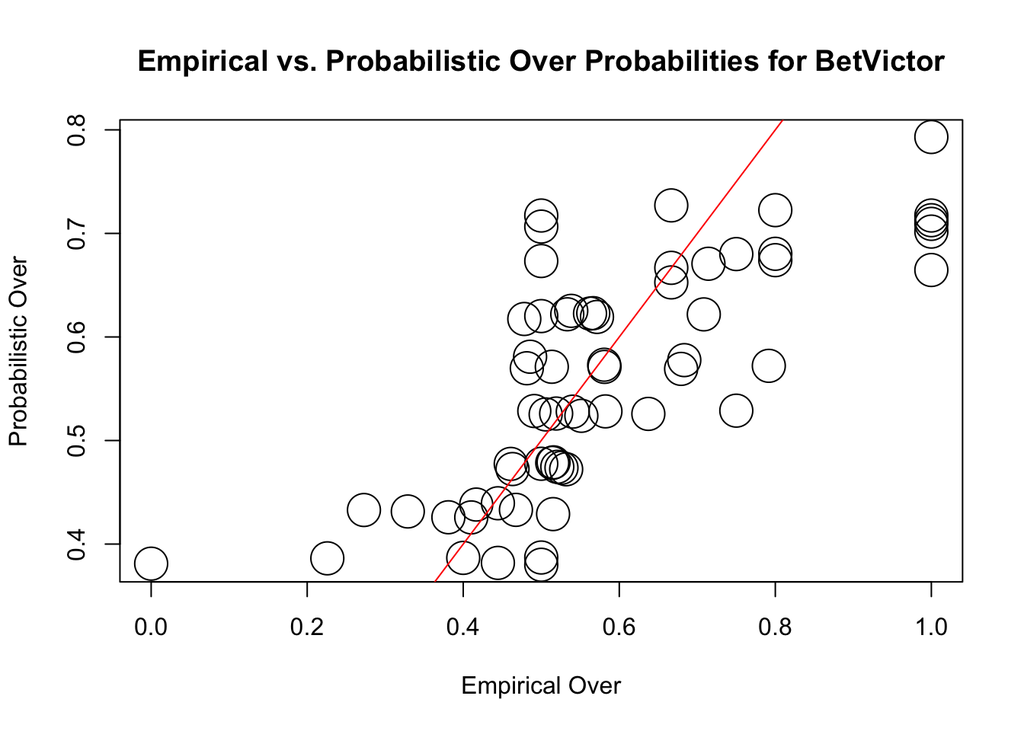

For final odds:

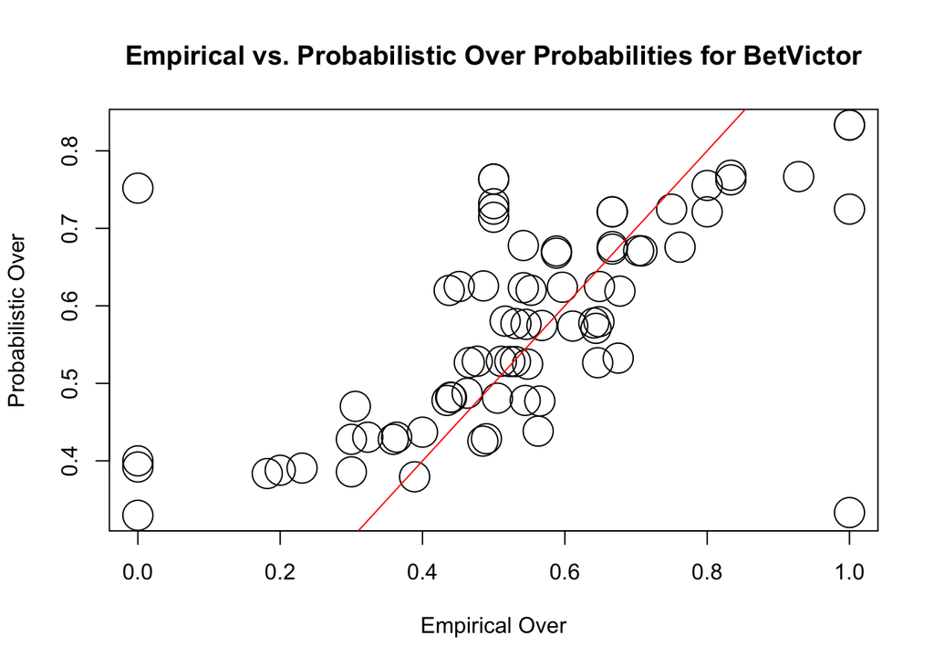

#### Betclic

For initial odds:

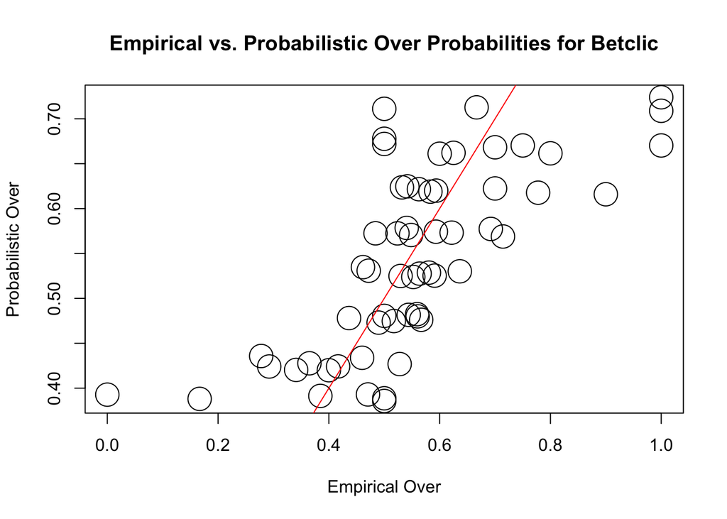

For final odds:

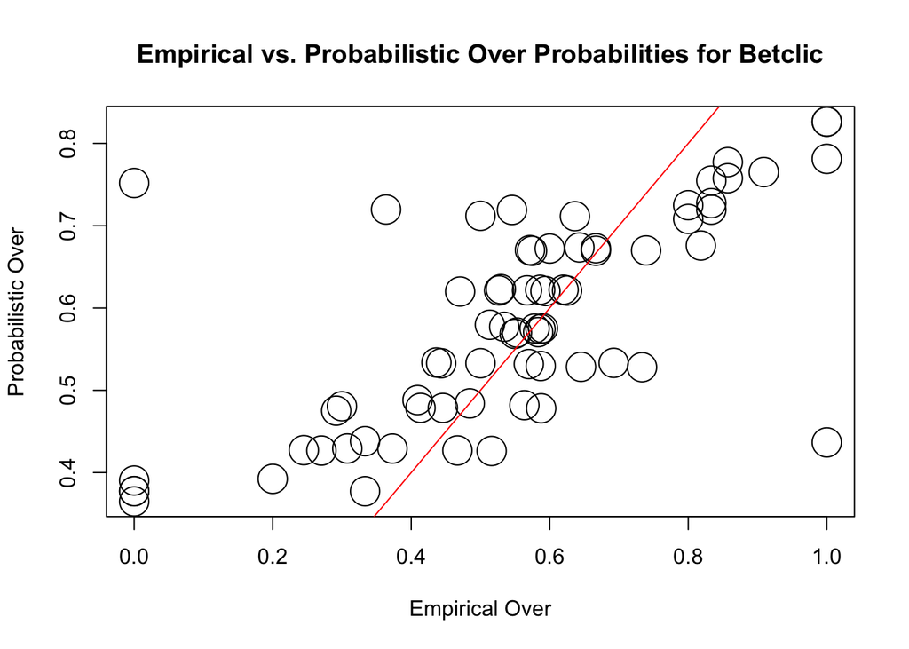

#### Betsafe

For initial odds:

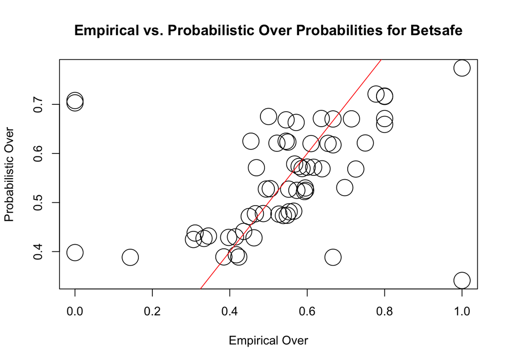

For final odds:

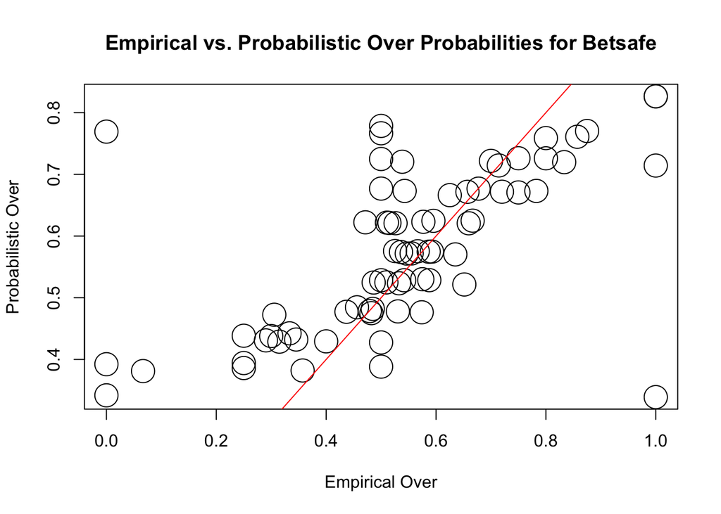

#### Sportingbet

For initial odds:

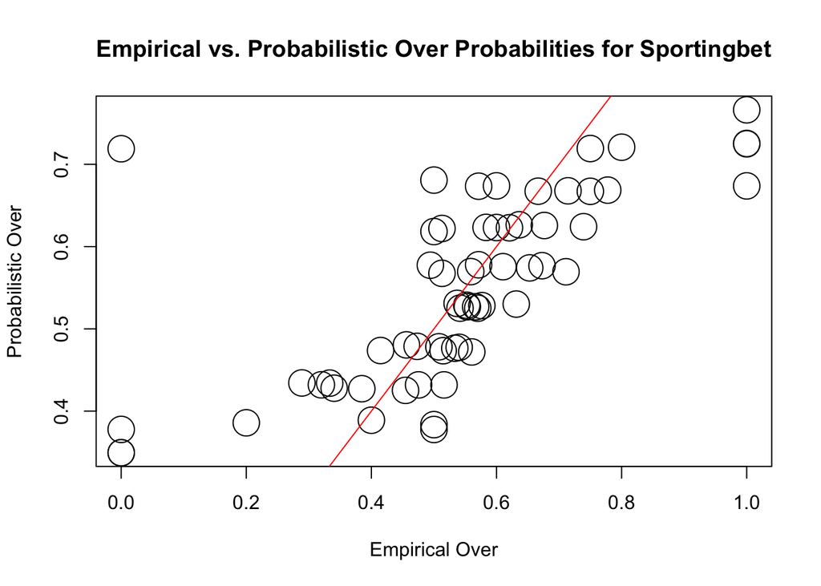

For final odds:

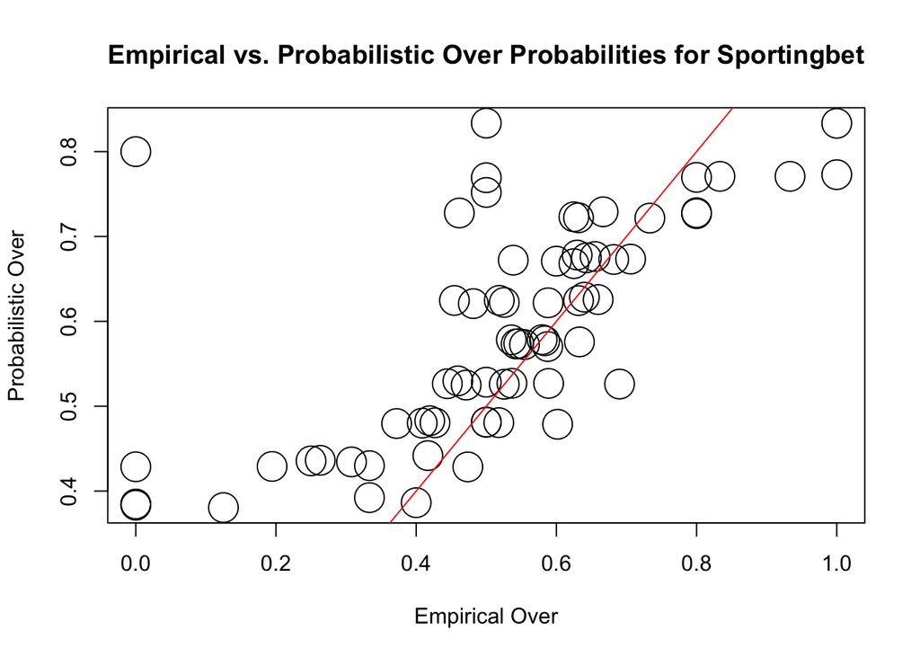

#### youwin

For initial odds:

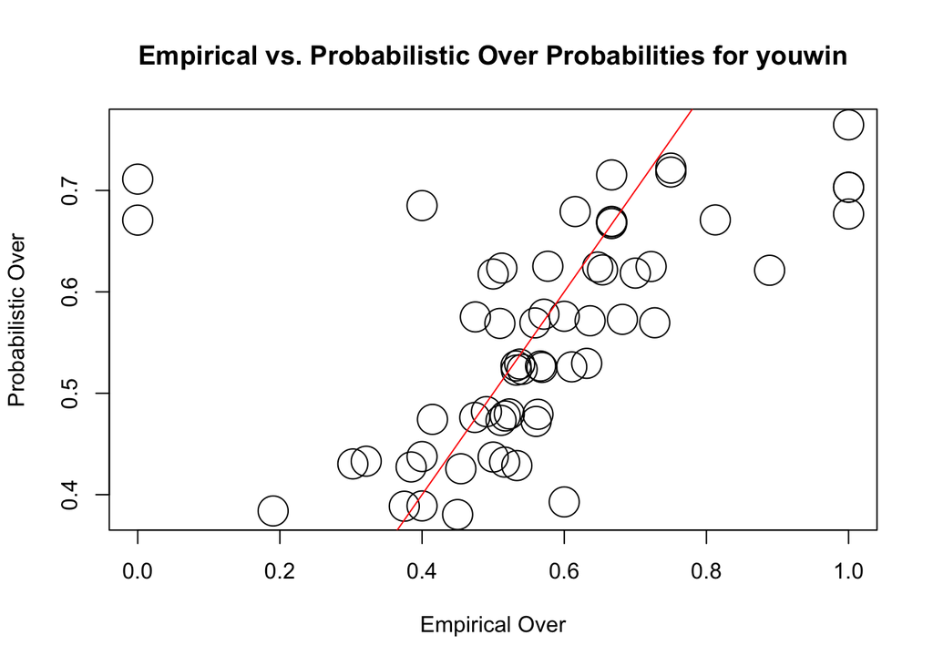

For final odds:

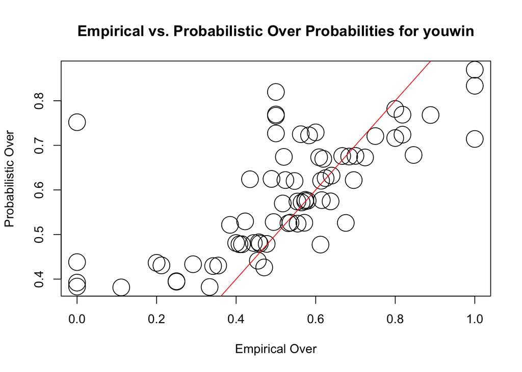

##### Summary:

It seems like in both of the plots for initial and final odds, the most of the points are around x=y line for each bookmaker. However, in the second plots the points are usually closer to the reference line (x=y) and therefore, we might say that bookmakers can update their odds succesfully with time.

While comparing bookmakers with each other, we can see that the points in the both plots of “Betclic” and “youwin” are more scattered around the reference line even though they have the same trend. Especially in the plots of “Betsafe” and “Sportingbet”, the points are more concentrated around x=y line. Therefore, we can conclude that “Betsafe” and “Sportingbet” are more successful than the other bookmakers in deciding over/under odds.

### Part B

In this part, I chose bookmaker “Betsafe” since it was one of the most successful bookmakers in the previous part. I checked whether it is consistently good at determining “over” probabilities during the given time period.

For the initial odds, following plots helps to compare the empirical results with the probabilistic results.

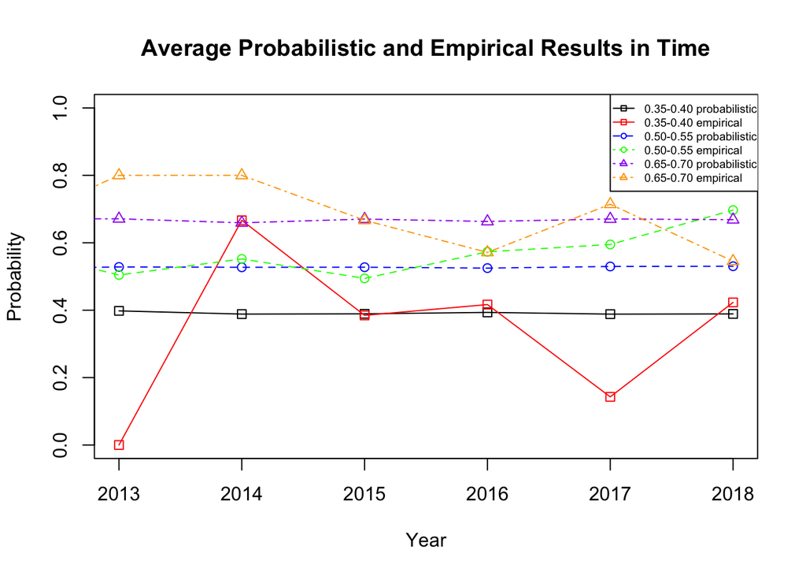

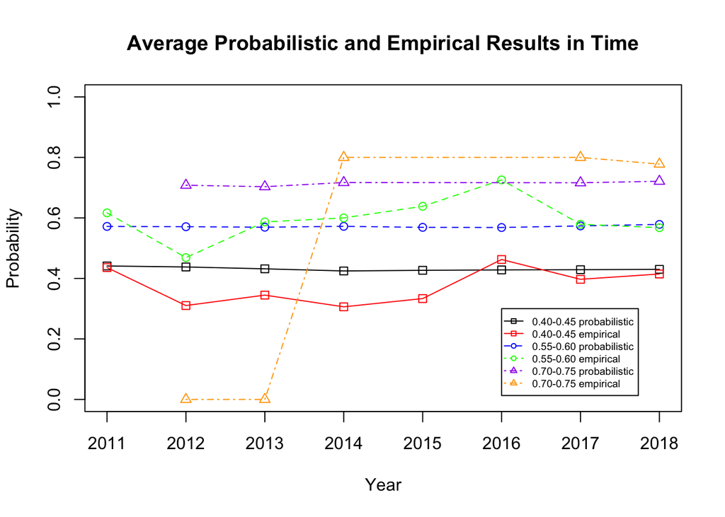

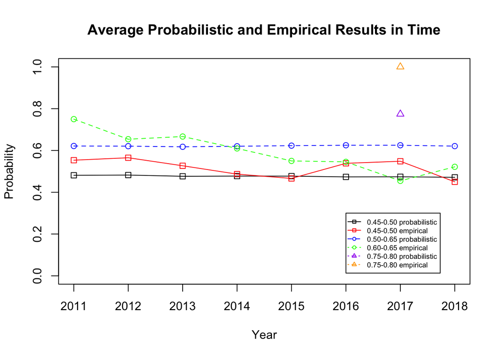

In these plots we can see that “Betsafe” makes good estimations about the match results. The averages of the empirical probabilities are close to the probabilistic results for each bin. The highest variations of the empirical probabilities is seen in the 0.35-0.40 bin and 0.70- 0.75 bin.

For the bins of 0.50-0.55, 0.55-0.60, the bookmaker might have underestimated and for the 0.40-0.45 bin it the bookmaker might have overestimated the implied probabilities.

# Task 2

To see the change of odds, we can filter the games with a high number of odds and by plotting them with the date they are made in the x-axis we can see the changes in the odds in time. There are 3 different type of odds for a match; odd1, odd2 and oddX. There is a relationship between those odds and it can be observed by plotting those odds in the same plot. We can also have a boxplot to see the variation of the odds.

To perform this task, I chose the bookmaker as “Sportingbet”. At first I’ve filtered the odds for match results with oddtype “1x2 bets” and ordered them based on the date they are made with following codes:

```r
odds_bet1x2=odds[betType=='1x2']
odds_bet1x2[,totalhandicap:=NULL]
odds_bet1x2=unique(odds_bet1x2)
merged_matches_bet1x2=merge(matches,odds_bet1x2,by='matchId')
merged_matches_bet1x2=merged_matches_bet1x2[order(matchId,bookmaker,oddtype,date)]
merged_matches_bet1x2_Sportingbet=merged_matches_bet1x2[bookmaker=='Sportingbet']
```

Then, I obtained the table listing the matches which has more than 90 odds in total as follows.

```
##      matchId oddtype NOdds TotalNOdds
##  1: YRuEyblb    odd1    96        286
##  2: YRuEyblb    odd2    97        286
##  3: YRuEyblb    oddX    93        286
##  4: Oz5rcBFr    odd1    58        178
##  5: Oz5rcBFr    odd2    60        178
##  6: Oz5rcBFr    oddX    60        178
##  7: 0hjYWZ2T    odd1     1        156
##  8: 0hjYWZ2T    odd2    78        156
##  9: 0hjYWZ2T    oddX    77        156
## 10: 4jOB2XiL    odd1    58        120
## 11: 4jOB2XiL    odd2    59        120
## 12: 4jOB2XiL    oddX     3        120
## 13: l6bmXCXh    odd1    31        104
## 14: l6bmXCXh    odd2    39        104
## 15: l6bmXCXh    oddX    34        104
## 16: v9xfFAyR    odd1    11         97
## 17: v9xfFAyR    odd2    10         97
## 18: v9xfFAyR    oddX    76         97
```

From those matches, I chose the first two matches since they have the highest amount of odds. Here are the plots of the first two matches for the different odd types.

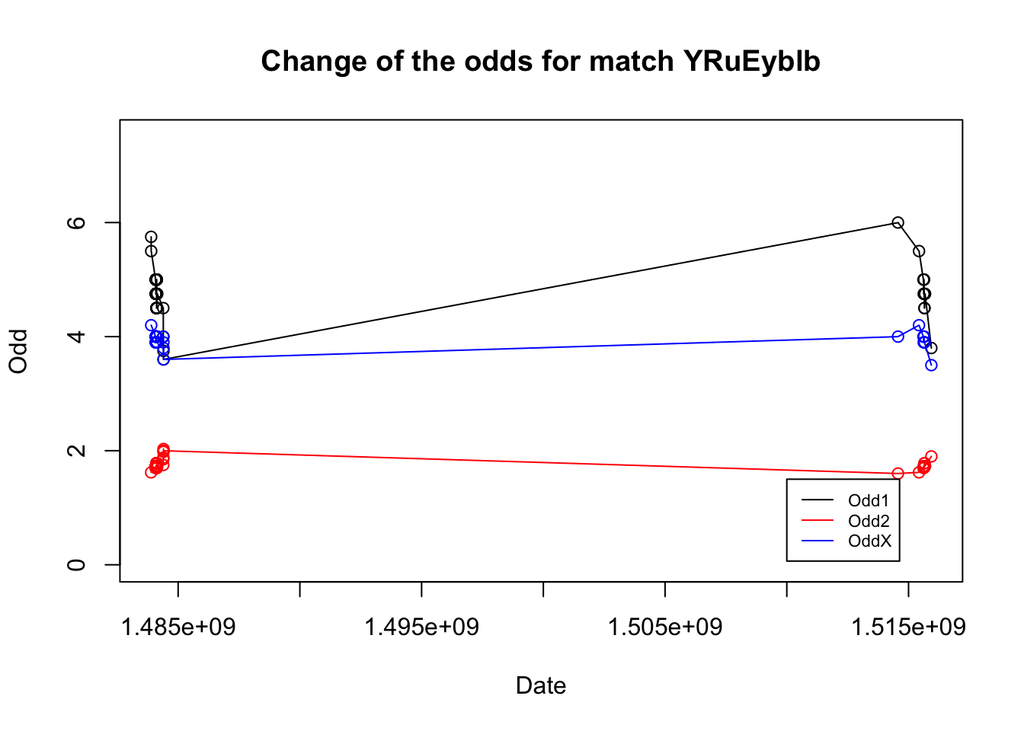

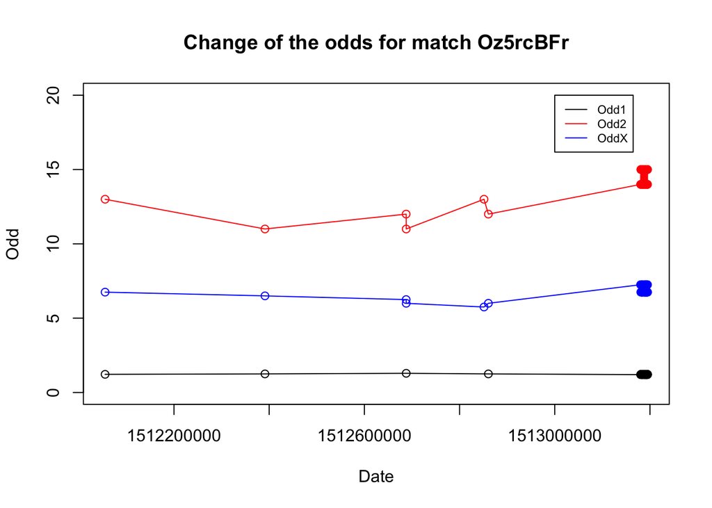

In the first plot we can observe that the odd1 which is the odd for the home team to win decreases at first. However, on a later date it is updated as a high amount again. We can observe the same situation in the oddX and the opposite situation in the odd2. Therefore, we can guess that some negative news obtained about the home team or some positive news about the away team are obtained in the time between those dates.

In the second plot all type of odds are remained almost constant except the odd2. It has a kind of trend to increase which may be interpreted as the believe in home team to win is increased in time. And the most of the odds are given at the end of this time horizon, probably during the match according to the current situation.

Here are the box plots for the odd types of two different matches:

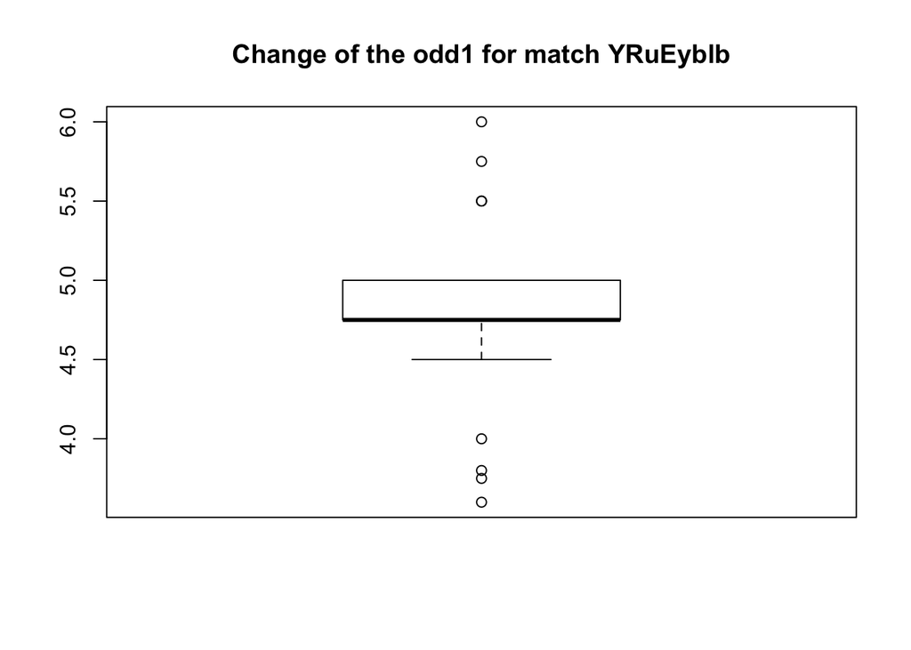

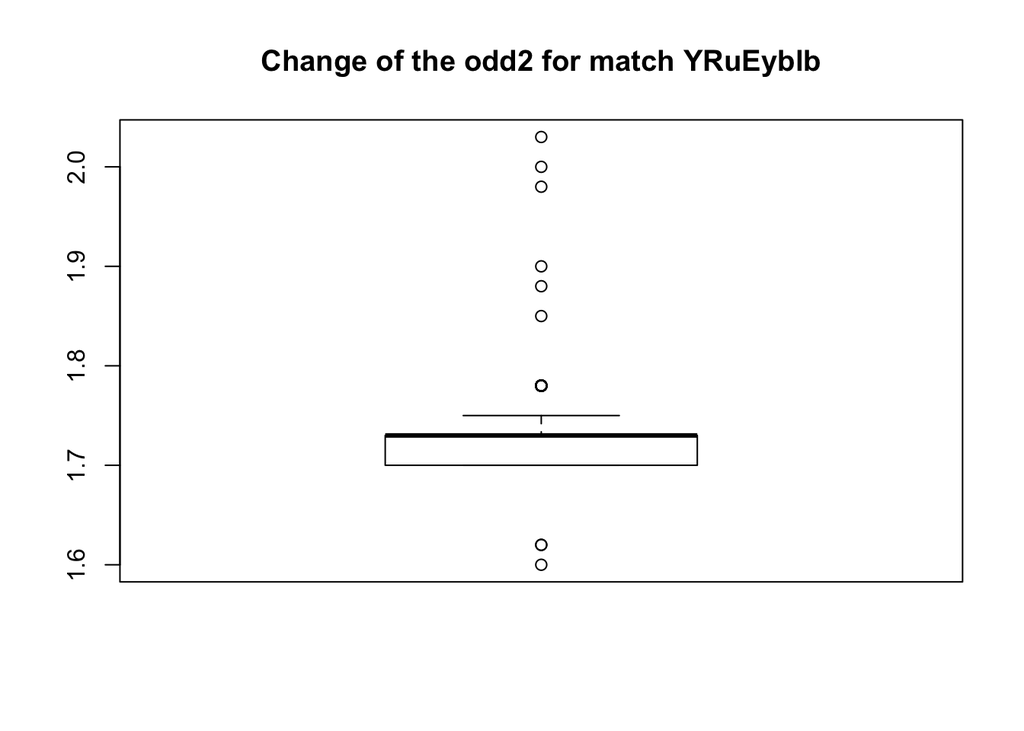

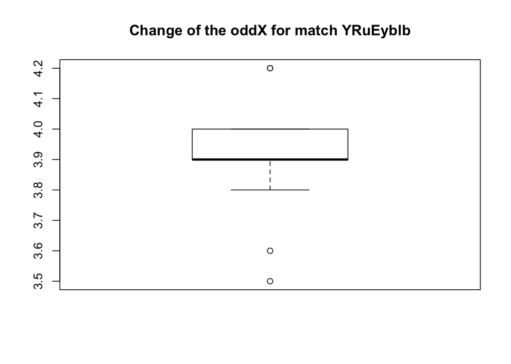

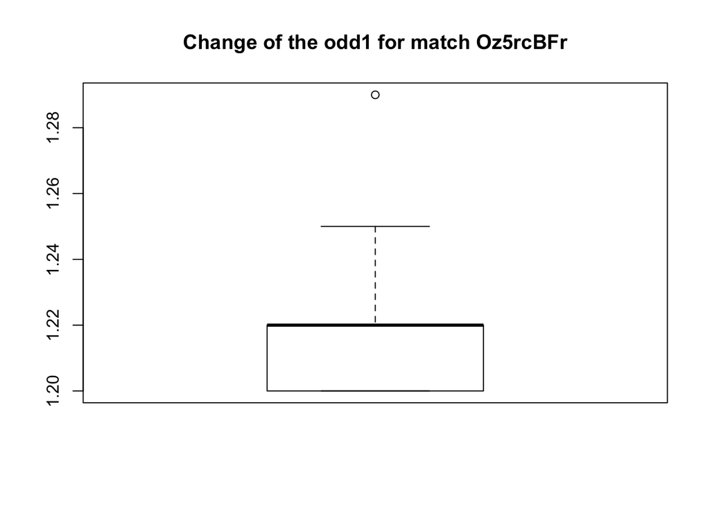

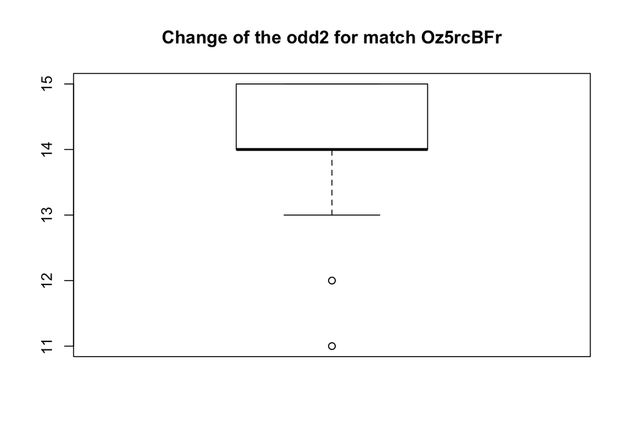

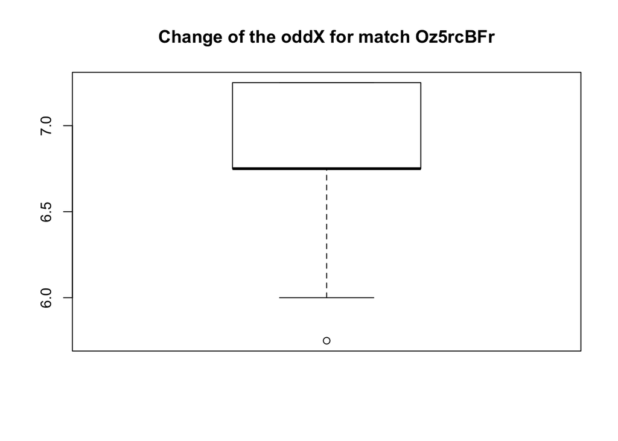